# Ebola Virus Envelope Protein Chimera… / Envelope glycoprotein

Fold-switch pair **1eboE_5fhcJ** — **1eboE** vs **5fhcJ**

Orthoebolavirus sp. / Ebola virus - Mayinga, Zaire, 1976

## Figure 1: Phylogenetic tree with per-cluster fold-preference heatmap.

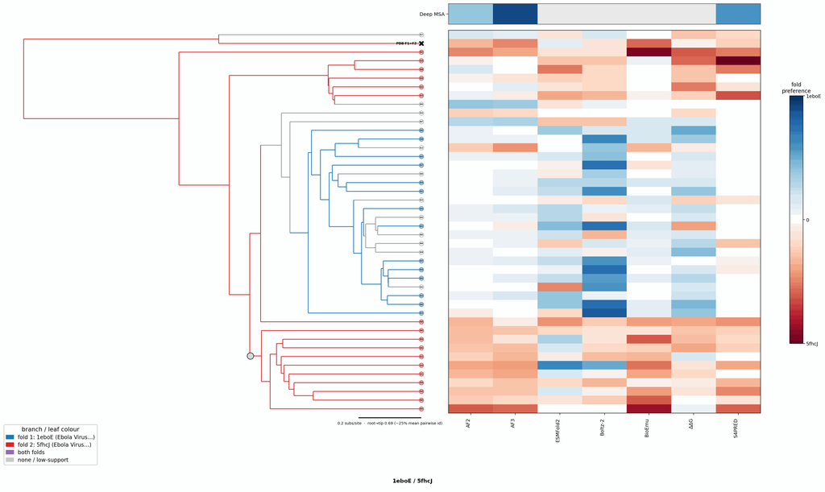

## Figure 2: Aligned overlay (both folds superposed)

The single fold-switching chain of each fold superposed by TM-align; waters hidden, any ligand shown as green sticks. Grey = structurally conserved core, colour = divergent (fold-switching) region.

1eboE (Ebola Virus Envelope Protein Chimera… / Envelope glycoprotein) · monomer5fhcJ (Ebola Virus Envelope Protein Chimera… / Envelope glycoprotein) · 6-mer

TM-score: 0.038 · Trigger class: mutation

Aligned overlay

Loading...

## Figure 3: The two folds, side by side

Each fold is coloured by per-residue Cα deviation between the two superposed structures: grey ≈ conserved core, full colour = structurally divergent (fold-switching) region.

1eboE (Ebola Virus Envelope Protein Chimera… / Envelope glycoprotein)

5fhcJ (Ebola Virus Envelope Protein Chimera… / Envelope glycoprotein)

0 Å5≥10 Å

1eboE (Ebola Virus Envelope Protein Chimera… / Envelope glycoprotein)

Loading...

5fhcJ (Ebola Virus Envelope Protein Chimera… / Envelope glycoprotein)

Loading...

## Figure 4: Best-cluster predicted contact maps over the two true folds.

Predicted contact maps (MSA-Transformer) for the clusters best matching each fold, over the true contacts of fold 1 (upper triangle) and fold 2 (lower). Divergent contacts between clusters are the contact-level signature of fold-switching.

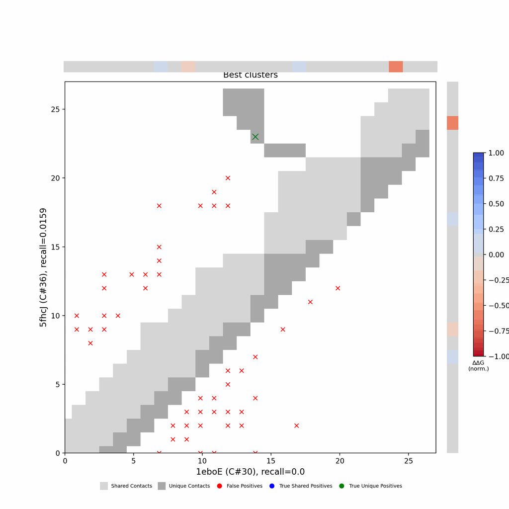

## Figure 5: Per-residue ΔΔG fold-preference contribution

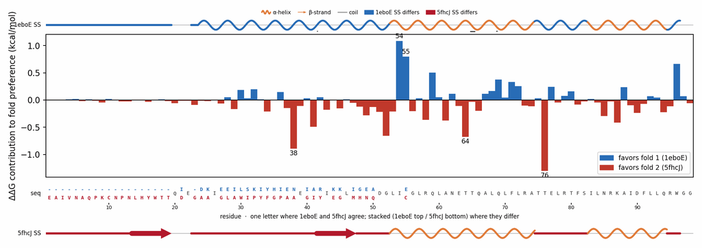

**More figures**

## Figure 6: Deep-MSA contact map panel / Best clusters contact map panel

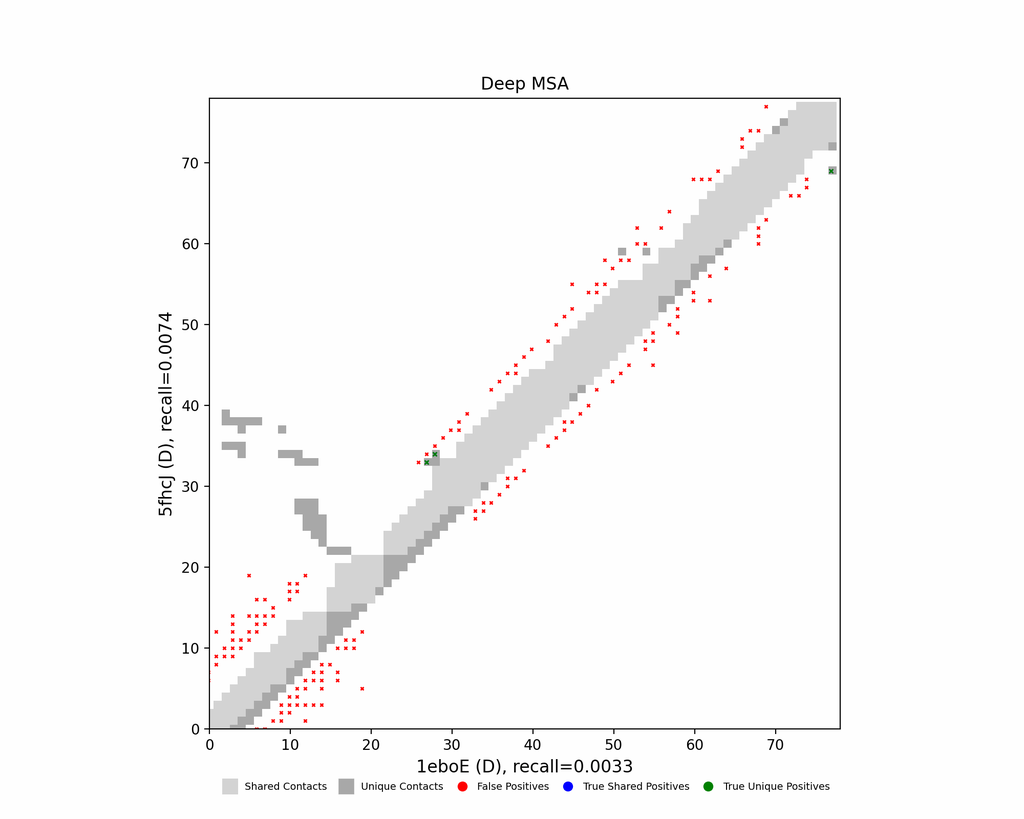

Deep-MSA contact map panel

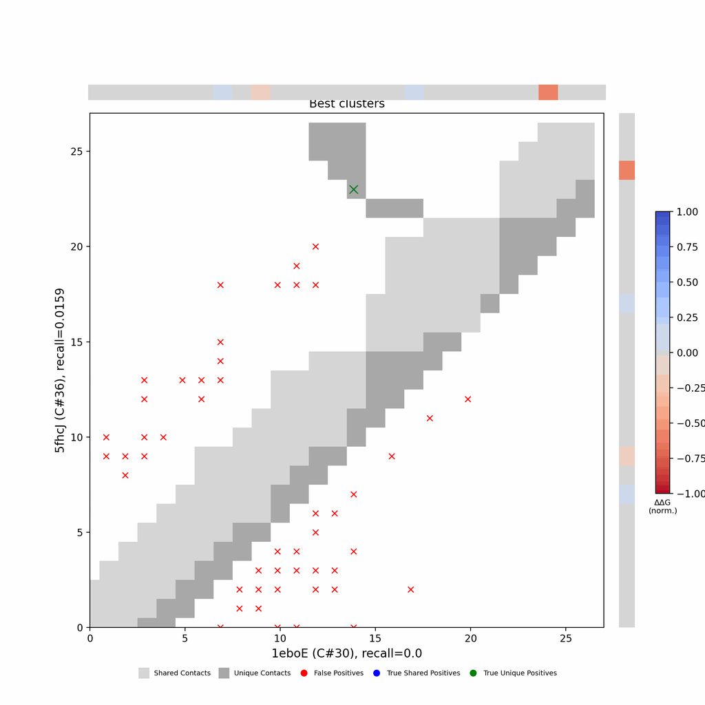

Best clusters contact map panel

## Figure 7: All clusters contact-map mosaic (small multiples).

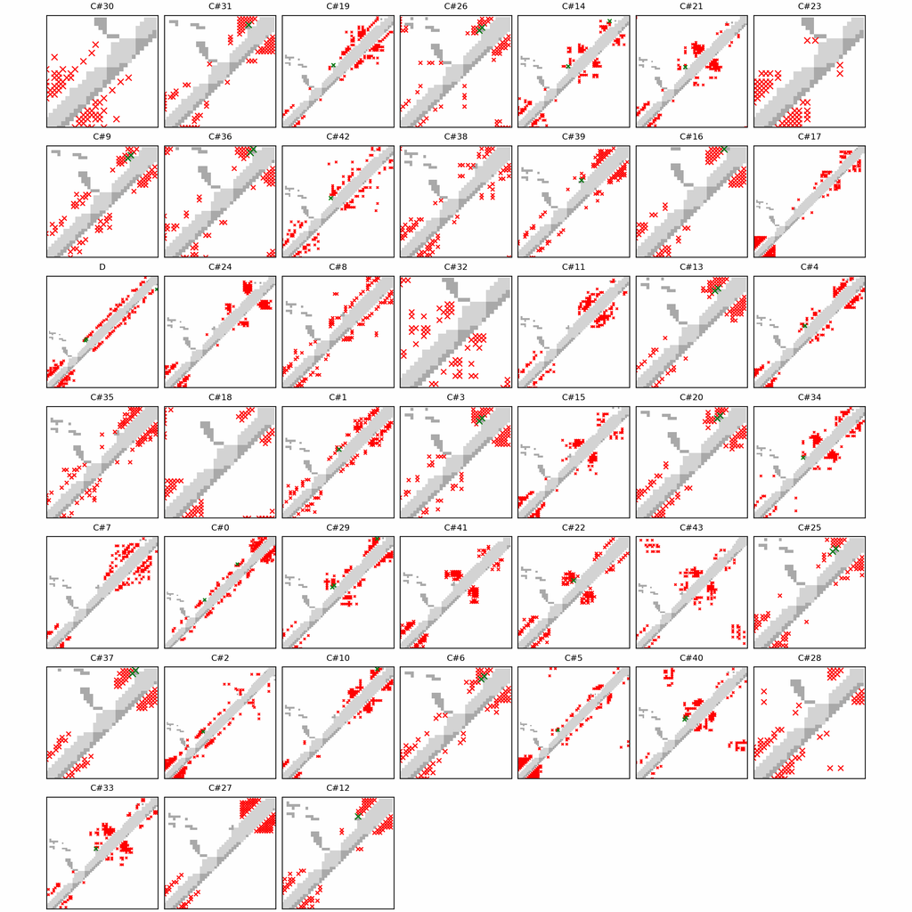

## Figure 8: Phylo null: tree with shuffled cluster fold labels.

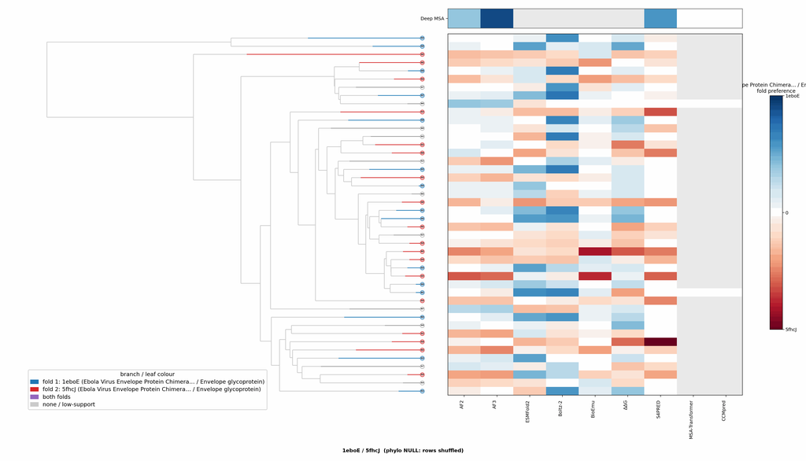

## Cluster metrics table

Per-cluster metrics underlying the figures above.

| cluster | n | neff | AF2_TM1 | AF2_TM2 | AF3_TM1 | AF3_TM2 | RE-MSAT-COM | RE-MSAT1 | RE-MSAT2 | ESM_SEQIDS | ESM_TM1 | ESM_TM2 | ΔΔG_Bias | ΔΔG_Bias_std | ΔΔG_frac_F1 | Boltz2_pref | S4PRED_pref | CCMpred_pref | BioEmu_pref |
| --- | --- | --- | --- | --- | --- | --- | --- | --- | --- | --- | --- | --- | --- | --- | --- | --- | --- | --- | --- |
| Deep | - | - | 0.84 | 0.6 | 0.79 | 0.27 | 0.0 | 0.05 | 0.0 | - | - | - | - | - | - | - | 0.4 | 0.0 | - |
| 000 | 103.0 | 43.0 | 0.87 | 0.25 | 0.82 | 0.24 | 0.0 | 0.0 | 0.0 | 001; 001; 002; 002; 003; 003; 004; 004; 005; 005 | 0.73 ± 0.11 | 0.25 ± 0.01 | -4.13 | 5.09 | 0.3 | 0.06 | 0.41 | 0.0 | 0.17 |
| 001 | 67.0 | 20.0 | 0.65 | 0.27 | 0.58 | 0.25 | 0.0 | 0.0 | 0.0 | 004; 004; 002; 002; 001; 001; 007; 006; 005; 005 | 0.47 ± 0.04 | 0.24 ± 0.01 | -8.2 | 5.47 | 0.0 | 0.21 | 0.41 | 0.0 | 0.21 |
| 002 | 52.0 | 5.0 | 0.42 | 0.25 | 0.38 | 0.28 | 0.0 | 0.0 | 0.0 | - | - | - | -4.42 | 4.39 | 0.1 | 0.02 | 0.23 | - | 0.05 |
| 003 | 42.0 | 3.0 | 0.64 | 0.24 | 0.67 | 0.24 | 0.0 | 0.0 | 0.0 | - | - | - | -1.33 | 1.08 | 0.1 | 0.16 | 0.4 | - | 0.19 |
| 004 | 36.0 | 16.0 | 0.45 | 0.25 | 0.54 | 0.24 | 0.0 | 0.0 | 0.0 | - | - | - | -7.12 | 2.36 | 0.0 | 0.01 | 0.25 | - | 0.04 |
| 005 | 34.0 | 7.0 | 0.33 | 0.25 | 0.38 | 0.24 | 0.0 | 0.0 | 0.0 | - | - | - | -10.19 | 4.83 | 0.0 | 0.01 | 0.03 | - | -0.02 |
| 006 | 34.0 | 2.0 | 0.67 | 0.24 | 0.65 | 0.24 | 0.0 | 0.0 | 0.0 | - | - | - | -2.05 | 1.68 | 0.1 | -0.04 | 0.41 | - | 0.2 |
| 007 | 31.0 | 4.0 | 0.8 | 0.25 | 0.81 | 0.25 | 0.0 | 0.0 | 0.0 | - | - | - | -2.33 | 6.33 | 0.5 | -0.02 | 0.41 | - | 0.2 |
| 008 | 31.0 | 2.0 | 0.77 | 0.26 | 0.63 | 0.27 | 0.0 | 0.0 | 0.0 | - | - | - | -6.87 | 5.89 | 0.3 | -0.01 | 0.03 | - | 0.18 |
| 009 | 30.0 | 1.0 | 0.65 | 0.26 | 0.66 | 0.24 | 0.0 | 0.0 | 0.0 | - | - | - | -1.24 | 1.49 | 0.4 | 0.08 | 0.19 | - | 0.18 |
| 010 | 26.0 | 4.0 | 0.64 | 0.27 | 0.65 | 0.24 | 0.0 | 0.0 | 0.0 | - | - | - | -2.16 | 2.88 | 0.3 | 0.1 | 0.4 | - | 0.2 |
| 011 | 24.0 | 1.0 | 0.65 | 0.3 | 0.64 | 0.25 | 0.0 | 0.0 | 0.0 | - | - | - | 0.05 | 3.83 | 0.5 | 0.23 | 0.37 | - | 0.2 |
| 012 | 23.0 | 14.0 | 0.47 | 0.25 | 0.38 | 0.26 | 0.0 | 0.0 | 0.0 | - | - | - | -4.76 | 3.24 | 0.0 | 0.13 | 0.41 | - | 0.11 |
| 013 | 23.0 | 1.0 | 0.67 | 0.25 | 0.68 | 0.24 | 0.0 | 0.0 | 0.0 | - | - | - | -1.83 | 1.98 | 0.2 | 0.05 | 0.4 | - | 0.17 |
| 014 | 23.0 | 13.0 | 0.42 | 0.28 | 0.41 | 0.28 | 0.0 | 0.0 | 0.0 | - | - | - | -5.69 | 2.65 | 0.0 | 0.15 | 0.12 | - | 0.06 |
| 015 | 22.0 | 8.0 | 0.67 | 0.26 | 0.62 | 0.29 | 0.0 | 0.0 | 0.0 | - | - | - | -6.44 | 1.09 | 0.0 | -0.04 | -0.05 | - | 0.17 |
| 016 | 22.0 | 1.0 | 0.64 | 0.24 | 0.61 | 0.25 | 0.0 | 0.0 | 0.0 | - | - | - | -2.44 | 2.77 | 0.3 | 0.21 | 0.35 | - | 0.18 |
| 017 | 22.0 | 14.0 | 0.78 | 0.31 | 0.69 | 0.26 | 0.0 | 0.0 | 0.0 | - | - | - | -6.77 | 5.46 | 0.1 | 0.07 | 0.25 | - | 0.18 |
| 018 | 21.0 | 17.0 | 0.63 | 0.27 | 0.63 | 0.26 | 0.0 | 0.0 | 0.05 | - | - | - | -9.76 | 3.34 | 0.0 | -0.02 | -0.3 | - | 0.18 |
| 019 | 21.0 | 5.0 | 0.64 | 0.28 | 0.59 | 0.3 | 0.0 | 0.0 | 0.0 | - | - | - | -6.75 | 3.56 | 0.0 | 0.0 | 0.38 | - | 0.18 |
| 020 | 21.0 | 2.0 | 0.66 | 0.24 | 0.66 | 0.24 | 0.0 | 0.0 | 0.0 | - | - | - | -2.23 | 2.93 | 0.3 | 0.02 | 0.39 | - | 0.17 |
| 021 | 20.0 | 11.0 | 0.44 | 0.26 | 0.43 | 0.28 | 0.0 | 0.0 | 0.0 | - | - | - | -6.09 | 2.03 | 0.0 | 0.03 | 0.41 | - | 0.1 |
| 022 | 20.0 | 14.0 | 0.64 | 0.25 | 0.7 | 0.26 | 0.0 | 0.0 | 0.0 | - | - | - | -9.23 | 2.52 | 0.0 | -0.01 | 0.3 | - | 0.17 |
| 023 | 17.0 | 12.0 | 0.64 | 0.26 | 0.64 | 0.26 | 0.0 | 0.0 | 0.0 | - | - | - | -6.34 | 1.58 | 0.0 | -0.0 | 0.28 | - | 0.21 |
| 024 | 16.0 | 15.0 | 0.48 | 0.24 | 0.51 | 0.26 | 0.0 | 0.0 | 0.0 | - | - | - | -5.99 | 4.13 | 0.2 | 0.03 | 0.4 | - | 0.17 |
| 025 | 15.0 | 5.0 | 0.68 | 0.27 | 0.66 | 0.25 | 0.0 | 0.0 | 0.0 | - | - | - | -2.64 | 0.98 | 0.0 | 0.13 | 0.4 | - | 0.18 |
| 026 | 15.0 | 8.0 | 0.66 | 0.24 | 0.68 | 0.24 | 0.0 | 0.0 | 0.0 | - | - | - | -1.5 | 1.48 | 0.2 | 0.06 | 0.4 | - | 0.19 |
| 027 | 15.0 | 13.0 | 0.66 | 0.28 | 0.63 | 0.26 | 0.0 | 0.0 | 0.0 | - | - | - | -2.88 | 3.56 | 0.2 | 0.21 | 0.41 | - | 0.15 |
| 028 | 14.0 | 9.0 | 0.64 | 0.22 | 0.62 | 0.27 | 0.0 | 0.0 | 0.0 | - | - | - | 0.38 | 1.25 | 0.7 | 0.03 | 0.4 | - | 0.2 |
| 029 | 14.0 | 6.0 | 0.49 | 0.22 | 0.45 | 0.24 | 0.0 | 0.0 | 0.0 | - | - | - | -4.65 | 1.68 | 0.0 | -0.03 | 0.16 | - | 0.17 |
| 030 | 13.0 | 10.0 | 0.67 | 0.27 | 0.67 | 0.26 | 0.0 | 0.0 | 0.0 | - | - | - | -2.84 | 2.61 | 0.1 | 0.11 | 0.41 | - | 0.18 |
| 031 | 13.0 | 4.0 | 0.66 | 0.26 | 0.67 | 0.25 | 0.0 | 0.0 | 0.0 | - | - | - | 0.05 | 1.5 | 0.6 | 0.18 | 0.41 | - | 0.18 |
| 032 | 13.0 | 2.0 | 0.63 | 0.25 | 0.63 | 0.25 | 0.0 | 0.0 | 0.0 | - | - | - | -2.29 | 1.5 | 0.1 | 0.17 | 0.41 | - | 0.17 |
| 033 | 13.0 | 5.0 | 0.46 | 0.23 | 0.45 | 0.28 | 0.0 | 0.0 | 0.0 | - | - | - | -2.34 | 2.05 | 0.1 | -0.03 | 0.4 | - | 0.11 |
| 034 | 13.0 | 6.0 | 0.48 | 0.27 | 0.48 | 0.27 | 0.0 | 0.0 | 0.0 | - | - | - | -5.07 | 1.89 | 0.0 | 0.03 | 0.05 | - | 0.09 |
| 035 | 13.0 | 1.0 | 0.23 | 0.23 | 0.23 | 0.19 | 0.0 | 0.0 | 0.0 | - | - | - | -3.58 | 1.49 | 0.0 | 0.04 | -0.02 | - | -0.01 |
| 036 | 12.0 | 2.0 | 0.65 | 0.26 | 0.62 | 0.24 | 0.0 | 0.0 | 0.0 | - | - | - | 0.53 | 1.37 | 0.6 | 0.21 | 0.41 | - | 0.2 |
| 037 | 12.0 | 6.0 | 0.68 | 0.26 | 0.67 | 0.24 | 0.0 | 0.0 | 0.04 | - | - | - | -3.9 | 2.5 | 0.0 | 0.17 | 0.36 | - | 0.19 |
| 038 | 12.0 | 7.0 | 0.68 | 0.28 | 0.64 | 0.24 | 0.0 | 0.0 | 0.0 | - | - | - | -0.35 | 1.84 | 0.5 | 0.18 | 0.4 | - | 0.2 |
| 039 | 12.0 | 6.0 | 0.67 | 0.26 | 0.64 | 0.24 | 0.0 | 0.0 | 0.0 | - | - | - | 1.08 | 4.16 | 0.6 | 0.07 | 0.4 | - | 0.21 |
| 040 | 12.0 | 10.0 | 0.48 | 0.3 | 0.58 | 0.25 | 0.0 | 0.0 | 0.0 | - | - | - | -7.94 | 1.03 | 0.0 | -0.02 | 0.08 | - | 0.08 |
| 041 | 12.0 | 7.0 | 0.44 | 0.24 | 0.44 | 0.25 | 0.0 | 0.0 | 0.0 | - | - | - | -8.14 | 2.95 | 0.0 | -0.0 | 0.22 | - | 0.13 |
| 042 | 12.0 | 1.0 | 0.49 | 0.27 | 0.52 | 0.26 | 0.0 | 0.0 | 0.0 | - | - | - | -4.15 | 1.02 | 0.0 | -0.02 | 0.32 | - | 0.05 |
| 043 | 12.0 | 9.0 | 0.45 | 0.26 | 0.46 | 0.25 | 0.0 | 0.0 | 0.03 | - | - | - | -6.86 | 2.71 | 0.0 | 0.01 | 0.23 | - | 0.15 |